# Bruhn_D03_2

### (a) 長方形の穴

扉を設けたり機器を取り付けたりするために、荷重を伝達するパネルに長方形の穴をあける必要があることがよくある。これらの穴は、当然ながら節 D3.6 で議論したように補強（フレーム）されなければならない。疲労の観点から同様に重要なのは、内角の半径が小さすぎないことである。さもないと、最終的にそこから裂け目（クラック）が発生する。任意の設計要件として、通常得られる仕上げにおいて、コーナー半径は $R = .35$ インチ以上に維持することが推奨される。より小さな半径がどうしても必要な場合には、最低限の限界として $R = .10$ を維持し、コーナーのパネルの端のまわりに f-40 仕上げを指定することが提案される。

### (b) 凹型パネル（リセスパネル）

図 D3.34 に示すように、機器を取り付けるために構造パネルの一部を局所的に凹ませる必要がある場合がある。

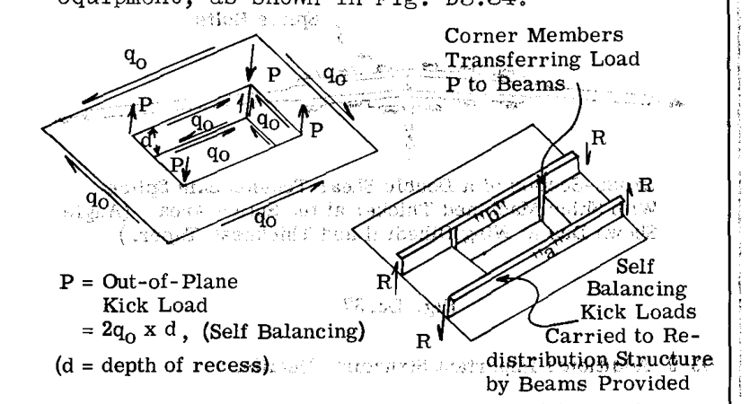

Fig. D3.34

凹型パネルは、剪断荷重を伝達し続けることができるが、面外への「キック」荷重が発生する。これらは図に示すように補強部材「a」および「b」によって支持され、荷重をメインのサイドパネルに再分配できる梁またはフレームに伝達される。凹部が非常に深く、そのサイズが大きすぎない場合は、パネルを省略して、生じた穴のまわりを単に補強する方が良い場合がある。これは、著しく座屈する外板が関与している場合に特に当てはまる。凹型パネルは、当然ながら引張応力を負担することはできず、剪断のみを負担する。凹部における元々の外板の穴は、上で議論した (a) のように鋭い角を持ってはならない。

### (c) 外板への軸力部材の取り付け

全体構造の主曲げ応力の方向（すなわち、胴体においては前後方向）にある局所的な軸力部材が取り付けられる場合は、常に注意が必要である。この部材は「有効」になろうとする傾向がある。つまり、外板が引き伸ばされる（特に引張下において）につれて、それとともに引張応力を発生させる。拾われる荷重の大部分は、部材の端部近くのファスナーを介して伝達される。部材は、取り付けられているパネルと同じ量だけ引き伸ばされようとするが、ファスナーの柔軟性のために完全に同じにはならない。したがって、最大荷重は上限として次式のようになる。

$$P = f_{\text{skin}} \times A_{\text{member}}$$

しかし、通常は外板の軸方向応力の 60% から 80% のみが部材に発生する。部材が大きく、その長さが長いほど、発生する軸方向荷重は大きくなる。この荷重の大部分は、両端の外側（端部）20% のファスナーを介して伝達されると考えられる。したがって、ここでは高荷重と比較的大きな支圧応力が発生する。これらが外板の高引張応力とともに外板パネルに存在する場合、外板パネルの疲労寿命は低下する。したがって、これらの誘導されたファスナー荷重を低く抑えるために、軸力部材（主構造以外のもの）は実用的な限り短く保つべきである。もしそれらの断面積が大きい場合は、端部をテーパー状にすべきである。これらの影響をより具体的に評価する方法はあるが、本稿の範囲外である。発生する可能性のある有害な影響を予測しておく必要がある。これは、パネルにクラックを引き起こすことがあるためである。

部材が座屈（対角引張）剪断パネル上に取り付けられる場合は、外板が座屈することによる作用で生じる「強制局部圧壊（forced crippling）」破壊の可能性を防ぐのに十分な強度を持たなければならない。読者は、設計基準に関して、この点について第 C11 章を参照されたい。

### (d) スポット溶接ダブラー

局所的な剪断流が高いために、外板または床パネルの一部のベイ（区画）または領域を、他のベイよりも厚くしなければならないことが頻繁にある。例えば、図 D3.35 に示すように、荷重が高いために、あるベイにおいて .040 厚さの外板を .064 にしなければならない場合がある。

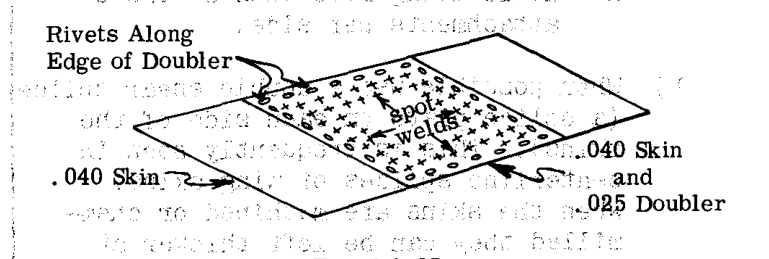

Fig. D3.35

大型パネルにおいて、これを達成するための一般的な方法の一つは、.040 の外板に .025 のダブラーをスポット溶接（時には接着）することである。スポット溶接は、2枚の独立した外板としてではなく、一体となって機能するように、密な間隔で配置されるべきである。2枚の独立した外板になると弱くなってしまう。ダブラーの端に沿ってリベットを使用することは、特にパネルが座屈を伴う引張フィールド設計である場合には、良い設計手法とされる。

### (e) 引張外板の継手

外板の継手（スプライス）は最小限にとどめるべきであるが、航空機構造においては一般的である。主要な構造外板の継手は、常に応力集中を含み疲労寿命を制限するため、十分な考慮が払われるべきである。

引張継手には、疲労寿命を低下させる2つの要因が存在する：

- 1. 結合される外板における基本的な引張応力と、穴による応力集中。
- 2. ファスナーの継手荷重による、穴における支圧応力。これが状況を悪化させる。すなわち、外板における引張応力と高い支圧応力の組み合わせは、引張応力単独の場合よりも悪い。

疲労寿命をできるだけ長く保つために、以下の慣行を守るべきである：

- 1. 通常のように、片側につき複数列のファスナーが必要とされる場合：
  1. 図 D3.36 に示すように、ファスナーの配置を「千鳥（スタッガード）」にせず、穴を一列に揃える。これにより、千鳥配置の穴よりも応力集中が低くなる。荷重の方向に一列に並んだ2つ以上の穴は、単一の穴よりも応力集中係数が低くなるというのは興味深い事実である。
  2. 片側あたりの取り付け列数は3列以下にする。
- 2. 可能な場合は、両面剪断継手（外板の両側にスプライスプレートを配置する）を使用する。これは、翼外板のセンターライン継手でよく見られる。外板が機械加工または化学研磨（ケミカルミーリング）されている場合、図 D3.37 に示すように、継手部分で厚く残すことで、局所的な引張応力と支圧応力を低減することができる。

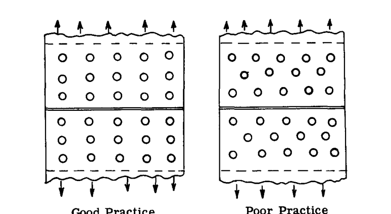

Fig. D3.36

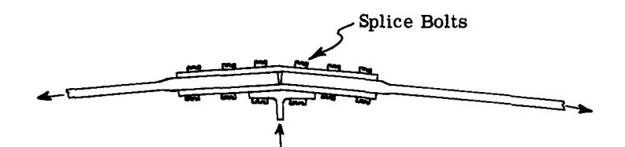

Fig. D3.37

- 3. 各列内および列間のファスナー間隔を、ファスナー直径の約4倍に維持する（列同士の間隔は実用的な限り近づけるべきである）。

## D3.9 その他の重要な構造設計のディテール

以下の詳細リストは、「推奨される慣行（good practice）」の代表例として、最小限の解説とともに提示されている。以下のリストに加えて、第 B25 章「疲労解析とフェイルセーフ設計」に記載されている詳細事項も遵守されるべきである。

1. 同じパターン内で、穴充填型ファスナーと非穴充填型ファスナー（例：アルミ製リベットとハイシェアタイプのリベット、またはスチール製ボルト）を混用することは避ける。これが避けられない場合は、非穴充填型ファスナーの穴をリーマ仕上げして、単にドリルで開けただけの「ガタ」のある穴よりも荷重を適切に負担できるようにする。
2. パターン内の非穴充填型ファスナーが4個未満の場合は、ファスナー間の荷重分配をより良くするために、リーマ仕上げされた穴を使用する。
3. $D/t$ （ファスナー直径と板厚の比）の値が 5.5 より大きい薄板でファスナーを使用する場合は、試験から許容値を決定するか、控えめな外挿値を使用する。薄板は、比較的低い支圧応力において穴の周囲で「座屈」する傾向がある。
4. 底面外板に皿モミ（ディンプル）加工が施されているジョイントでは、ハイシェアタイプ（hi-shear）のファスナーを使用しない。
5. 荷重の不均一な分配を考慮して、剪断ジョイントのファスナーパターンにおいては、任意の安全余裕を .15 に維持する。
6. ミサイルのような「使い捨て（one-shot）」構造が関与している場合を除き、座屈する外板を支持フレームに取り付けるためにスポット溶接を使用しない。このような場合でも、ジョグル（段曲げ）部材のジョグル部の両側でスポット溶接を使用せず、ジョグル部にはリベットを使用する。
7. 継手において、一列に「長く連なった」ファスナーを使用しない。このような場合、端部のファスナーが最初に荷重を受け持ち、早期に降伏する。慎重にテーパーが施され、徹底的に解析された継手を使用しない限り、片側あたり3個、または最大でも4個のファスナーが上限である。そのような設計は可能であるが、本稿の範囲外である。
8. すべてのフィッティング設計において、ナイフエッジ（フェザーエッジ）が生じないよう細心の注意を払う。凹角状の交差部は、端部を丸める必要があり、さもないと疲労クラックが必然的に発生する。面と面の間の角度が 70度 未満の場合は、ナイフエッジとみなすことができる。これらは、設計において監視されていない場合、穴あけやその他の機械加工操作の指示においてよく発生する。
9. 第 C11 章に提示されている恒久的な座屈データは、外板の曲率半径に対して下部構造のリングが密に配置されている、胴体に類似した構造に適用される。すなわち、外板支持間隔と曲率半径の比が1よりもかなり小さい場合である。下部構造の間隔が大きくなると、初期座屈を引き起こすのとほぼ同じ剪断応力において恒久的な座屈が発生すると考えるべきである。すなわち、上記の比が1に近づくときである。
10. 捩り（トルク）が存在する場合は、「開断面」部材の使用を避ける。第 A6 章からわかるように、開断面部材は閉断面と比較して極めて柔軟である。特定のねじり剛性に対して、開断面部材は閉断面のものよりもはるかに重くなる。以下の例において、両端に純ねじりが作用する場合、部材「b」は部材「a」の 65倍 の剛性を持つ（第 A6 章の例も参照）。

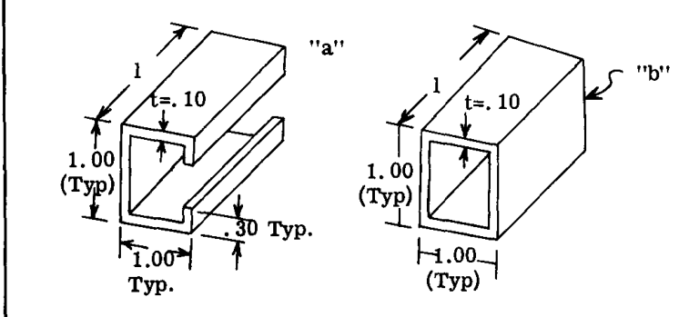

Fig. D3.38

閉断面であっても効率的に機能させるためには、ねじりが閉断面のすべての面に分散される必要がある。これには、「バルクヘッド」型の端部フィッティング、またはねじりが入力される場所の局所的な肉厚を大幅に厚くすることが必要になる場合がある。この作用は、胴体のバルクヘッドがねじり荷重を胴体外板に分配する、あるいは翼のロブ（リブ）が加えられたねじりを外板やスパーウェブに分配するのと同様である。

11. 圧縮座屈は必ずしも破壊を意味しない。追加の荷重を受け持ち続ける他の部材が存在しない場合にのみ破壊を意味する。剪断座屈は、第 C11 章で議論されているように、追加の荷重が対角引張として担持されなければならないことを示しているにすぎない。当然ながら、ウェブを支持する部材は、その結果として生じるいわゆる「二次的」影響に耐えることができなければならない。

胴体や主翼の圧縮外板が座屈すると、それらは追加の圧縮荷重を担持しなくなるが、第 A19 章で議論されているように、ストリンガーやフランジは依然としてこれを担持可能である。座屈した外板は、テンションフィールド作用を通じて追加の剪断荷重を担持することができる。したがって、軽量で効率的な設計を達成するために、設計者は、部材が座屈した後に発生する要因（本書の他の章でカバーされている）について深い理解を持つべきである。

12. 詳細な構造設計に関して、おそらく最も重要な単一の事項は、平衡（つり合い）の問題である。設計者が、組立部品のすべての部分について荷重のつり合いを示すことができれば、ほとんどの誤りは防ぐことができる。構造強度の問題の大部分は、単に静力学の法則が遵守されていないために発生しており、これを行うための時間が割かれないのは、通常、小さな詳細部品においてである。計算尺やデータブックの代わりに「目視（直感）」を安全に使用できるようになるには、かなりの経験が必要である。設計を始めたばかりの詳細設計者や、ある程度の経験を積んだ人であっても、単にこの経験を持ち合わせていないことが多い。構造設計のすべての分野において、このような状況における唯一の安全な道は、常に構造アセンブリのすべての部品について、部材の荷重が静的つり合い状態にあることを示すことである。これが行われれば、荷重下で構造が実際にどのように変形しているかについて、設計者はより良い感覚を得ることができる。これは、部材が結合され、荷重がかかったときに互いに押し合ったり、引き合ったり、こじり合ったりするような問題を予測する上で、非常に有益な助けとなる。

### 参考文献

1. “Theory of Elastic Stability”, Timoshenko. “Buckling of Metal Structures”, Bleich, F.